# NumPy

Lecture 06

Dr. Colin Rundel

## What is NumPy?

> NumPy is the fundamental package for scientific computing in Python. It is a Python library that provides a multidimensional array object, various derived objects (such as masked arrays and matrices), and an assortment of routines for fast operations on arrays, including mathematical, logical, shape manipulation, sorting, selecting, I/O, discrete Fourier transforms, basic linear algebra, basic statistical operations, random simulation and much more.

```python
import numpy as np
np.__version__
```

```
'2.4.1'
```

## Arrays

In general NumPy arrays are constructed from sequences (e.g. lists), nesting as necessary for the number of desired dimensions.

```python
np.array([1,2,3])
```

```
array([1, 2, 3])
```

```python
np.array([[1,2],[3,4]])
```

```
array([[1, 2],
       [3, 4]])
```

```python
np.array([[[1,2],[3,4]], [[5,6],[7,8]]])
```

```
array([[[1, 2],
        [3, 4]],

       [[5, 6],
        [7, 8]]])
```

```python
np.array([1.0, 2.5, np.pi])
```

```
array([1.        , 2.5       , 3.14159265])
```

```python
np.array([[True], [False]])
```

```
array([[ True],
       [False]])
```

```python
np.array(["abc", "def"])
```

```
array(['abc', 'def'], dtype='<U3')
```

Note that NumPy stores data in row major order.

## Some properties of NumPy arrays:

- Arrays have a fixed size at creation
- All data must be homogeneous (consistent type)
- Built to support vectorized operations
- Avoids copying whenever possible (inplace operations)

## dtype

Calling `type()` on any NumPy array returns `numpy.ndarray` - the specific type stored in the array is recorded as the array’s `dtype`. This is accessible via the `dtype` attribute and can be set at creation using the `dtype` argument.

```python
np.array([1,1]).dtype
```

```
dtype('int64')
```

```python
np.array([1.1, 2.2]).dtype
```

```
dtype('float64')
```

```python
np.array([True, False]).dtype
```

```
dtype('bool')
```

```python
np.array([3.14159, 2.33333],
         dtype = np.double)
```

```
array([3.14159, 2.33333])
```

```python
np.array([3.14159, 2.33333],
         dtype = np.float16)
```

```
array([3.14 , 2.334], dtype=float16)
```

```python
np.array([1,2,3], dtype = np.uint8)
```

```
array([1, 2, 3], dtype=uint8)
```

See [here](https://numpy.org/doc/stable/user/basics.types.html#array-types-and-conversions-between-types) for a list of dtypes and [here](https://numpy.org/doc/stable/reference/arrays.dtypes.html) for a more detailed description of how they are implemented.

## dtypes and overflow

Some types have a maximum and/or minimum value that can be stored in them.

If you try to create an array with a value outside of this range you will get an overflow error.

```python
np.array([-1, 1,2], dtype = np.uint8)
```

```
OverflowError: Python integer -1 out of bounds for uint8
```

```python
np.array([1,2,1000], dtype = np.uint8)
```

```
OverflowError: Python integer 1000 out of bounds for uint8
```

If you are instead coercing values using `astype()` you will *not* get this error.

```python
np.array([-1, 1,2,1000]).astype(np.uint8)
```

```
array([255,   1,   2, 232], dtype=uint8)
```

## Creating 1d arrays

Some common functions and methods for creating 1d arrays:

```python
np.arange(10)
```

```
array([0, 1, 2, 3, 4, 5, 6, 7, 8, 9])
```

```python
np.arange(3, 5, 0.25)
```

```
array([3.  , 3.25, 3.5 , 3.75, 4.  , 4.25, 4.5 , 4.75])
```

```python
np.linspace(0, 1, 11)
```

```
array([0. , 0.1, 0.2, 0.3, 0.4, 0.5, 0.6, 0.7, 0.8, 0.9, 1. ])
```

```python
np.logspace(0, 2, 4)
```

```
array([  1.        ,   4.64158883,  21.5443469 , 100.        ])
```

```python
np.ones(4)
```

```
array([1., 1., 1., 1.])
```

```python
np.zeros(6)
```

```
array([0., 0., 0., 0., 0., 0.])
```

```python
np.full(3, False)
```

```
array([False, False, False])
```

```python
np.empty(4)
```

```
array([1., 1., 1., 1.])
```

For the full list of creation functions see [here](https://numpy.org/doc/stable/reference/routines.array-creation.html)

## Creating 2d arrays (matrices)

Many of the same functions exist with some additional useful tools for common matrices.

```python
np.eye(3)
```

```
array([[1., 0., 0.],
       [0., 1., 0.],
       [0., 0., 1.]])
```

```python
np.identity(2)
```

```
array([[1., 0.],
       [0., 1.]])
```

```python
np.zeros((2,2))
```

```
array([[0., 0.],
       [0., 0.]])
```

```python
np.diag([3,2,1])
```

```
array([[3, 0, 0],
       [0, 2, 0],
       [0, 0, 1]])
```

```python
np.tri(3)
```

```
array([[1., 0., 0.],
       [1., 1., 0.],
       [1., 1., 1.]])
```

```python
np.triu(np.full((3,3),3))
```

```
array([[3, 3, 3],
       [0, 3, 3],
       [0, 0, 3]])
```

The NumPy documentation references a `matrix` class and related functions - this is no longer recommended, use the `ndarray` class instead.

## Creating $n$d arrays

For higher dimensional arrays just add dimensions when constructing,

```python
np.zeros((2,3,2))
```

```
array([[[0., 0.],
        [0., 0.],
        [0., 0.]],

       [[0., 0.],
        [0., 0.],
        [0., 0.]]])
```

```python
np.ones((2,3,2,2))
```

```
array([[[[1., 1.],
         [1., 1.]],

        [[1., 1.],
         [1., 1.]],

        [[1., 1.],
         [1., 1.]]],

       [[[1., 1.],
         [1., 1.]],

        [[1., 1.],
         [1., 1.]],

        [[1., 1.],
         [1., 1.]]]])
```

## Subsetting

Arrays are subsetted using the standard python syntax with either indexes or slices, dimensions are separated by commas.

```python
x = np.array([[1,2,3],[4,5,6],[7,8,9]])
x
```

```
array([[1, 2, 3],
       [4, 5, 6],
       [7, 8, 9]])
```

```python
x[0]
```

```
array([1, 2, 3])
```

```python
x[0,0]
```

```
np.int64(1)
```

```python
x[0][0]
```

```
np.int64(1)
```

```python
x[0:3:2, :]
```

```
array([[1, 2, 3],
       [7, 8, 9]])
```

```python
x[0:3:2, :]
```

```
array([[1, 2, 3],
       [7, 8, 9]])
```

```python
x[0:3:2, ]
```

```
array([[1, 2, 3],
       [7, 8, 9]])
```

```python
x[1:, ::-1]
```

```
array([[6, 5, 4],
       [9, 8, 7]])
```

## Views and copies

Basic subsetting of ndarray objects does not result in a new object, but instead a “view” of the original object. There are a couple of ways that we can investigate this behavior,

```python
x = np.arange(10)
y = x[2:5]
z = x[2:5].copy()
```

```python
f"{x=}, {x.base=}"
```

```
'x=array([0, 1, 2, 3, 4, 5, 6, 7, 8, 9]), x.base=None'
```

```python
f"{y=}, {y.base=}"
```

```
'y=array([2, 3, 4]), y.base=array([0, 1, 2, 3, 4, 5, 6, 7, 8, 9])'
```

```python
f"{z=}, {z.base=}"
```

```
'z=array([2, 3, 4]), z.base=None'
```

```python
type(x), type(y), type(z)
```

```
(<class 'numpy.ndarray'>, <class 'numpy.ndarray'>, <class 'numpy.ndarray'>)
```

```python
np.shares_memory(x,y)
```

```
True
```

```python
np.shares_memory(x,z)
```

```
False
```

```python
np.shares_memory(y,z)
```

```
False
```

```python
y.flags
```

```
  C_CONTIGUOUS : True
  F_CONTIGUOUS : True
  OWNDATA : False
  WRITEABLE : True
  ALIGNED : True
  WRITEBACKIFCOPY : False
```

## Subsetting with …

Generally in Python we cannot include an empty argument - to select all elements with numpy we use `:`.

To avoid having to type excess `:` you can use `...` which expands to the number of `:` needed to account for all remaining dimensions,

```python
x = (np.arange(16)
     .reshape(2,2,2,2))
x
```

```
array([[[[ 0,  1],
         [ 2,  3]],

        [[ 4,  5],
         [ 6,  7]]],

       [[[ 8,  9],
         [10, 11]],

        [[12, 13],
         [14, 15]]]])
```

```python
x[0, 1, , ]
```

```
invalid syntax (<string>, line 1)
```

```python
x[0, 1, :, ]
```

```
array([[4, 5],
       [6, 7]])
```

```python
x[0, 1, :, :]
```

```
array([[4, 5],
       [6, 7]])
```

```python
x[0, 1, ...]
```

```
array([[4, 5],
       [6, 7]])
```

```python
x[, :, :, 1]
```

```
invalid syntax (<string>, line 1)
```

```python
x[:, :, :, 1]
```

```
array([[[ 1,  3],
        [ 5,  7]],

       [[ 9, 11],
        [13, 15]]])
```

```python
x[..., 1]
```

```
array([[[ 1,  3],
        [ 5,  7]],

       [[ 9, 11],
        [13, 15]]])
```

## Subsetting with tuples

Unlike lists, an ndarray can be subset by a tuple containing integers,

```python
x = np.arange(6); x
```

```
array([0, 1, 2, 3, 4, 5])
```

```python
x[(0,1,3),]
```

```
array([0, 1, 3])
```

```python
x[(3,5,1,0),]
```

```
array([3, 5, 1, 0])
```

```python
x[(0,1,3)]
```

```
IndexError: too many indices for array: array is 1-dimensional, but 3 were indexed
```

```python
x = np.arange(16).reshape((4,4))
x
```

```
array([[ 0,  1,  2,  3],
       [ 4,  5,  6,  7],
       [ 8,  9, 10, 11],
       [12, 13, 14, 15]])
```

```python
x[(0,1,3), :]
```

```
array([[ 0,  1,  2,  3],
       [ 4,  5,  6,  7],
       [12, 13, 14, 15]])
```

```python
x[:, (0,1,3)]
```

```
array([[ 0,  1,  3],
       [ 4,  5,  7],
       [ 8,  9, 11],
       [12, 13, 15]])
```

```python
x[(0,1,3), (0,1,3)]
```

```
array([ 0,  5, 15])
```

More on why `x[(0,1,3)]` does not work later.

## Subsetting assignment

Most of the subsetting approaches we’ve just seen can also be used for assignment, just keep in mind that we cannot change the *size* or *type* of the `ndarray`,

```python
x = np.arange(9).reshape((3,3)); x
```

```
array([[0, 1, 2],
       [3, 4, 5],
       [6, 7, 8]])
```

```python
x[0,0] = -1; x
```

```
array([[-1,  1,  2],
       [ 3,  4,  5],
       [ 6,  7,  8]])
```

```python
x[0, :] = -2; x
```

```
array([[-2, -2, -2],
       [ 3,  4,  5],
       [ 6,  7,  8]])
```

```python
x[0:2,1:3] = -3; x
```

```
array([[-2, -3, -3],
       [ 3, -3, -3],
       [ 6,  7,  8]])
```

```python
x[(0,1,2), (0,1,2)] = -4; x
```

```
array([[-4, -3, -3],
       [ 3, -4, -3],
       [ 6,  7, -4]])
```

```python
x[0,0] = "A"
```

```
ValueError: invalid literal for int() with base 10: 'A'
```

## Reshaping arrays

The dimensions of an array can be retrieved via the `shape` attribute, these values can be changed via the `reshape()` method or updating `shape`

```python
x = np.arange(6); x
```

```
array([0, 1, 2, 3, 4, 5])
```

```python
y = x.reshape((2,3)); y
```

```
array([[0, 1, 2],
       [3, 4, 5]])
```

```python
x
```

```
array([0, 1, 2, 3, 4, 5])
```

```python
np.shares_memory(x,y)
```

```
True
```

```python
z = x
z.shape = (2,3); z
```

```
array([[0, 1, 2],
       [3, 4, 5]])
```

```python
x
```

```
array([[0, 1, 2],
       [3, 4, 5]])
```

```python
np.shares_memory(x,z)
```

```
True
```

## Implicit dimensions

When reshaping an array, the value `-1` can be used to automatically calculate a dimension,

```python
x = np.arange(6); x
```

```
array([0, 1, 2, 3, 4, 5])
```

```python
x.reshape((2,-1))
```

```
array([[0, 1, 2],
       [3, 4, 5]])
```

```python
x.reshape((-1,3,2))
```

```
array([[[0, 1],
        [2, 3],
        [4, 5]]])
```

```python
x.reshape(-1)
```

```
array([0, 1, 2, 3, 4, 5])
```

```python
x.reshape((-1,4))
```

```
ValueError: cannot reshape array of size 6 into shape (4)
```

## Flattening arrays

We just saw one of the more common approaches to creating a flat *view* of an array (`reshape(-1)`), there are two other common methods / functions:

- `ravel` creates a flattened *view* of the array and
- `flatten` creates a flattened *copy* of the array.

```python
w = np.arange(6).reshape((2,3)); w
```

```
array([[0, 1, 2],
       [3, 4, 5]])
```

```python
x = w.reshape(-1)
x
```

```
array([0, 1, 2, 3, 4, 5])
```

```python
np.shares_memory(w,x)
```

```
True
```

```python
y = w.ravel()
y
```

```
array([0, 1, 2, 3, 4, 5])
```

```python
np.shares_memory(w,y)
```

```
True
```

```python
z = w.flatten()
z
```

```
array([0, 1, 2, 3, 4, 5])
```

```python
np.shares_memory(w,z)
```

```
False
```

## Resizing

The size of an array cannot be changed but a new array with a different size can be created from an existing array via the `resize` function and method. Note these have different behaviors around what values the new entries will have.

```python
x = np.resize(
  np.ones((2,2)),
  (3,3)
)
x
```

```
array([[1., 1., 1.],
       [1., 1., 1.],
       [1., 1., 1.]])
```

```python
y = np.ones(
  (2,2)
).resize(
  (3,3)
)
y
```

Why didn’t this 2nd version work?

## More details

```python
y = np.ones(
  (2,2)
)
y.resize((3,3))
```

```
ValueError: cannot resize an array that references or is referenced
by another array in this way.
Use the np.resize function or refcheck=False
```

```python
y
```

```
array([[1., 1.],
       [1., 1.]])
```

```python
y.resize((1,4))
y
```

```
array([[1., 1., 1., 1.]])
```

## Joining arrays

`concatenate()` is a general purpose function for joining arrays, with specialized versions `vstack()`, `hstack()`, and `dstack()` for rows, columns, and slices respectively.

```python
x = np.arange(4).reshape((2,2)); x
```

```
array([[0, 1],
       [2, 3]])
```

```python
y = np.arange(4,8).reshape((2,2)); y
```

```
array([[4, 5],
       [6, 7]])
```

```python
np.concatenate((x,y), axis=0)
```

```
array([[0, 1],
       [2, 3],
       [4, 5],
       [6, 7]])
```

```python
np.concatenate((x,y), axis=1)
```

```
array([[0, 1, 4, 5],
       [2, 3, 6, 7]])
```

```python
np.vstack((x,y))
```

```
array([[0, 1],
       [2, 3],
       [4, 5],
       [6, 7]])
```

```python
np.hstack((x,y))
```

```
array([[0, 1, 4, 5],
       [2, 3, 6, 7]])
```

## Joining arrays (cont.)

```python
np.concatenate((x,y), axis=2)
```

```
numpy.exceptions.AxisError: axis 2 is out of bounds for array of dimension 2
```

```python
np.concatenate((x,y), axis=None)
```

```
array([0, 1, 2, 3, 4, 5, 6, 7])
```

```python
np.dstack((x,y))
```

```
array([[[0, 4],
        [1, 5]],

       [[2, 6],
        [3, 7]]])
```

# NumPy numerics

## Basic operators

All of the basic mathematical operators in Python are implemented for arrays, they are applied element-wise to the array values.

```python
np.arange(3) + np.arange(3)
```

```
array([0, 2, 4])
```

```python
np.arange(3) - np.arange(3)
```

```
array([0, 0, 0])
```

```python
np.arange(3) + 2
```

```
array([2, 3, 4])
```

```python
np.arange(3) * np.arange(3)
```

```
array([0, 1, 4])
```

```python
np.arange(1,4) / np.arange(1,4)
```

```
array([1., 1., 1.])
```

```python
np.arange(3) * 3
```

```
array([0, 3, 6])
```

```python
np.full((2,2), 2) ** np.arange(4).reshape((2,2))
```

```
array([[1, 2],
       [4, 8]])
```

```python
np.full((2,2), 2) ** np.arange(4)
```

```
ValueError: operands could not be broadcast together with shapes (2,2) (4,)
```

More on broadcasting next time

## Mathematical functions

NumPy provides a [wide variety](https://numpy.org/doc/stable/reference/routines.math.html) of basic mathematical functions that are vectorized, in general they will be faster than their base equivalents (e.g. `np.sum()` vs `sum()`),

```python
np.sum(np.arange(1000))
```

```
np.int64(499500)
```

```python
np.cumsum(np.arange(10))
```

```
array([ 0,  1,  3,  6, 10, 15, 21, 28, 36, 45])
```

```python
np.log10(np.arange(1,4))
```

```
array([0.        , 0.30103   , 0.47712125])
```

```python
np.median(np.arange(10))
```

```
np.float64(4.5)
```

## The `axis` parameter

Many aggregate functions accept an `axis` parameter that specifies which dimension to operate along. `axis=0` operates along rows (collapsing rows), `axis=1` along columns, etc. Using `axis=None` (the default) operates on the flattened array.

```python
x = np.arange(12).reshape((3,4)); x
```

```
array([[ 0,  1,  2,  3],
       [ 4,  5,  6,  7],
       [ 8,  9, 10, 11]])
```

```python
np.sum(x)
```

```
np.int64(66)
```

```python
np.sum(x, axis=0)
```

```
array([12, 15, 18, 21])
```

```python
np.sum(x, axis=1)
```

```
array([ 6, 22, 38])
```

```python
np.min(x)
```

```
np.int64(0)
```

```python
np.min(x, axis=0)
```

```
array([0, 1, 2, 3])
```

```python
np.min(x, axis=1)
```

```
array([0, 4, 8])
```

## Matrix multiplication

is supported using the `matmul()` function or the `@` operator,

```python
x = np.arange(6).reshape(3,2)
y = np.tri(2,2)
```

```python
x @ y
```

```
array([[1., 1.],
       [5., 3.],
       [9., 5.]])
```

```python
y.T @ y
```

```
array([[2., 1.],
       [1., 1.]])
```

```python
np.matmul(x.T, x)
```

```
array([[20, 26],
       [26, 35]])
```

```python
y @ x
```

```
ValueError: matmul: Input operand 1 has a mismatch in its core dimension 0, with gufunc signature (n?,k),(k,m?)->(n?,m?) (size 3 is different from 2)
```

## Other linear algebra functions

All of the other common linear algebra functions are (mostly) implemented in the `linalg` submodule.

```python
np.linalg.det(y)
```

```
np.float64(1.0)
```

```python
np.linalg.eig(x.T @ x)
```

```
EigResult(eigenvalues=array([ 0.43988174, 54.56011826]), eigenvectors=array([[-0.79911221, -0.6011819 ],
       [ 0.6011819 , -0.79911221]]))
```

```python
np.linalg.inv(x.T @ x)
```

```
array([[ 1.45833333, -1.08333333],
       [-1.08333333,  0.83333333]])
```

```python
np.linalg.cholesky(x.T @ x)
```

```
array([[4.47213595, 0.        ],
       [5.81377674, 1.09544512]])
```

See [here](https://numpy.org/doc/stable/reference/routines.linalg.html) for more details.

## Random values

NumPy has another submodule called `random` for functions used to generate random values.

In order to use this, you construct a generator via `default_rng()`, with or without a seed, and then use the generator’s methods to obtain your desired random values.

```python
rng = np.random.default_rng(seed = 1234)
```

```python
rng.random(3) # ~ Uniform [0,1)
```

```
array([0.97669977, 0.38019574, 0.92324623])
```

```python
rng.normal(loc=0, scale=2, size = (2,2))
```

```
array([[ 0.30523839,  1.72748778],
       [ 5.82619845, -2.95764672]])
```

```python
rng.binomial(n=5, p=0.5, size = 10)
```

```
array([2, 4, 2, 2, 3, 4, 4, 3, 3, 3])
```

# Advanced Indexing

## Advanced Indexing

> Advanced indexing is triggered when the selection object, `obj`, is a non-tuple sequence object, an ndarray (of data type integer or bool), or a tuple with at least one sequence object or ndarray (of data type integer or bool).
> - There are two types of advanced indexing: integer and Boolean.
> - Advanced indexing always returns a *copy* of the data (contrast with basic slicing that returns a view).

From NumPy - User Guide - [Advanced Indexing](https://numpy.org/doc/stable/user/basics.indexing.html#advanced-indexing)

## Integer array subsetting (lists)

Lists of integers can be used to subset in the same way:

```python
x = np.arange(16).reshape((4,4)); x
```

```
array([[ 0,  1,  2,  3],
       [ 4,  5,  6,  7],
       [ 8,  9, 10, 11],
       [12, 13, 14, 15]])
```

```python
x[[1,3]]
```

```
array([[ 4,  5,  6,  7],
       [12, 13, 14, 15]])
```

```python
x[[1,3], ]
```

```
array([[ 4,  5,  6,  7],
       [12, 13, 14, 15]])
```

```python
x[:, [1,3]]
```

```
array([[ 1,  3],
       [ 5,  7],
       [ 9, 11],
       [13, 15]])
```

```python
x[[0,1,3],]
```

```
array([[ 0,  1,  2,  3],
       [ 4,  5,  6,  7],
       [12, 13, 14, 15]])
```

```python
x[[0,1,3]]
```

```
array([[ 0,  1,  2,  3],
       [ 4,  5,  6,  7],
       [12, 13, 14, 15]])
```

```python
x[[1.,3]]
```

```
IndexError: only integers, slices (`:`), ellipsis (`...`), numpy.newaxis (`None`) and integer or boolean arrays are valid indices
```

## Integer array subsetting (ndarrays)

Similarly we can also use integer ndarrays:

```python
x = np.arange(6)
y = np.array([0,1,3])
z = np.array([1., 3.])
```

```python
x[y,]
```

```
array([0, 1, 3])
```

```python
x[y]
```

```
array([0, 1, 3])
```

```python
x[z]
```

```
IndexError: arrays used as indices must be of integer (or boolean) type
```

```python
x = np.arange(16).reshape((4,4))
y = np.array([1,3])
```

```python
x[y]
```

```
array([[ 4,  5,  6,  7],
       [12, 13, 14, 15]])
```

```python
x[y, ]
```

```
array([[ 4,  5,  6,  7],
       [12, 13, 14, 15]])
```

```python
x[:, y]
```

```
array([[ 1,  3],
       [ 5,  7],
       [ 9, 11],
       [13, 15]])
```

```python
x[y, y]
```

```
array([ 5, 15])
```

## Exercise 1

Given the following matrix,

```python
x = np.arange(16).reshape((4,4))
x
```

```
array([[ 0,  1,  2,  3],
       [ 4,  5,  6,  7],
       [ 8,  9, 10, 11],
       [12, 13, 14, 15]])
```

write an expression to obtain the center 2x2 values (i.e. 5, 6, 9, 10 as a matrix).

## Boolean indexing

Lists or ndarrays of boolean values can also be used to subset (positions with `True` are kept and `False` are discarded)

```python
x = np.arange(6); x
```

```
array([0, 1, 2, 3, 4, 5])
```

```python
x[[True, False, True, False, True, False]]
```

```
array([0, 2, 4])
```

```python
x[[True]]
```

```
IndexError: boolean index did not match indexed array along axis 0; size of axis is 6 but size of corresponding boolean axis is 1
```

```python
x[np.array([True, False, True, False, True, False])]
```

```
array([0, 2, 4])
```

```python
x[np.array([True])]
```

```
IndexError: boolean index did not match indexed array along axis 0; size of axis is 6 but size of corresponding boolean axis is 1
```

## Boolean expressions

The primary utility of boolean subsetting comes from vectorized comparison operations,

```python
x = np.arange(6); x
```

```
array([0, 1, 2, 3, 4, 5])
```

```python
x > 3
```

```
array([False, False, False, False,  True,  True])
```

```python
x[x>3]
```

```
array([4, 5])
```

```python
x % 2 == 1
```

```
array([False,  True, False,  True, False,  True])
```

```python
x[x % 2 == 1]
```

```
array([1, 3, 5])
```

```python
y = np.arange(9).reshape((3,3))
y % 2 == 0
```

```
array([[ True, False,  True],
       [False,  True, False],
       [ True, False,  True]])
```

```python
y[y % 2 == 0]
```

```
array([0, 2, 4, 6, 8])
```

## NumPy and Boolean operators

If we want to use a logical operators on an array we need to use `&`, `|`, and `~` instead of `and`, `or`, and `not` respectively.

```python
x = np.arange(6); x
```

```
array([0, 1, 2, 3, 4, 5])
```

```python
y = (x % 2 == 0); y
```

```
array([ True, False,  True, False,  True, False])
```

```python
~y
```

```
array([False,  True, False,  True, False,  True])
```

```python
y & (x > 3)
```

```
array([False, False, False, False,  True, False])
```

```python
y | (x > 3)
```

```
array([ True, False,  True, False,  True,  True])
```

## `np.where()`

`np.where()` is a vectorized conditional selection function. With three arguments it acts like an element-wise if-else, returning values from one of two arrays based on a condition.

```python
x = np.arange(10); x
```

```
array([0, 1, 2, 3, 4, 5, 6, 7, 8, 9])
```

```python
np.where(x % 2 == 0, x, -1)
```

```
array([ 0, -1,  2, -1,  4, -1,  6, -1,  8, -1])
```

```python
np.where(x > 5, "big", "small")
```

```
array(['small', 'small', 'small', 'small', 'small', 'small', 'big', 'big',
       'big', 'big'], dtype='<U5')
```

```python
np.where(x < 3)
```

```
(array([0, 1, 2]),)
```

With a single argument, `np.where()` returns the indices where the condition is `True` (equivalent to `np.nonzero()`).

## meshgrid()

One other useful function in NumPy is `meshgrid()` which generates all possible combinations between the input vectors (as a tuple of ndarrays),

```python
pts = np.arange(3)
x, y = np.meshgrid(pts, pts)
```

```python
x
```

```
array([[0, 1, 2],
       [0, 1, 2],
       [0, 1, 2]])
```

```python
y
```

```
array([[0, 0, 0],
       [1, 1, 1],
       [2, 2, 2]])
```

```python
np.sqrt(x**2 + y**2).round(3)
```

```
array([[0.   , 1.   , 2.   ],
       [1.   , 1.414, 2.236],
       [2.   , 2.236, 2.828]])
```

## Exercise 2

We will now use this to attempt a simple brute force approach to numerical optimization, define a grid of points using `meshgrid()` to approximate the minimum of the following function:

$$f(x,y) = (1-x)^2 + 100(y-x^2)^2$$
Considering values of $x,y \in (-1,3)$, which value(s) of $x,y$ minimize this function?

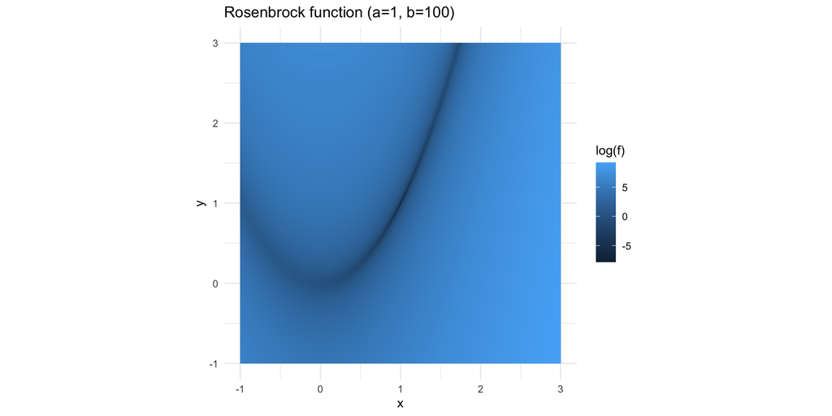